# Modelowanie / regresja multiplikatywna

# Regresja liniowa - kontynuacja

Analizując rzeczywiste dane, często możemy spotkać sytuacje w których zależność pomiędzy zmiennymi nie wygląda na liniową. Również w takich sytuacjach regresja jest użytecznym narzędziem, ponieważ często zależności można sprowadzić do liniowych wykonując transformacje zmiennych.

Jak? O tym poniżej.

W tej części będziemy bazować na przykładach dotyczących cen samochodów. Wczytajmy dane.

## Wczytanie danych

W naszym zbiorze danych znajdują się oferty sprzedaży bardzo różnych marek. Analizowanie ich wszystkich w jednym worku nie ma sensu. Dlatego dalsze analizy przeprowadzimy na podzbiorze danych dotyczącym marki Volkswagen. Dlaczego tej? Jest ona najpopularniejsza w zebranych ogłoszeniach.

```r
library(SmarterPoland)      # w tym pakiecie znajduje się zbiór danych auta2012
volkswagen <- auta2012 %>%
  filter(Marka == "Volkswagen")
head(volkswagen, 2)
```

```
## Source: local data frame [2 x 21]
##
##    Cena Waluta Cena.w.PLN Brutto.netto  KM  kW      Marka    Model Wersja
## 1 79900    PLN      79900        netto 175 129 Volkswagen Multivan
## 2 13600    PLN      13600       brutto  NA  NA Volkswagen     Golf     IV
## Variables not shown: Liczba.drzwi (fctr), Pojemnosc.skokowa (dbl),
##   Przebieg.w.km (dbl), Rodzaj.paliwa (fctr), Rok.produkcji (dbl), Kolor
##   (fctr), Kraj.aktualnej.rejestracji (fctr), Kraj.pochodzenia (fctr),
##   Pojazd.uszkodzony (fctr), Skrzynia.biegow (fctr),
##   Status.pojazdu.sprowadzonego (fctr), Wyposazenie.dodatkowe (fctr)
```

Każdy wiersz tego zbioru danych opisuje jedną ofertę sprzedaży auta. Każda kolumna opisuje jedną cechę / właściwość tej oferty.

## Jaka to zależność?

Zobaczmy jak wygląda zależność ceny of wieku volkswagena. W naszym zbiorze danych nie ma zmiennej wiek, jest jedynie wiek produkcji. Wiedząc, że te oferty były zbierane w styczniu 2012 roku łatwo nam będzie wyznaczyć wiek auta. Zacznijmy więc od wyznaczenia zmiennej wiek auta, a następnie usunięcia aut ponad 20 letnich (mało ich jest i będą nam przeszkadzać w modelowaniu).

```r
volkswagen <- volkswagen %>%
  mutate(Wiek = 2012 - Rok.produkcji) %>%
  filter(Wiek < 20)
```

Wykorzystamy funkcję `lm()`, którą poznaliśmy w poprzednim module, do wyznaczenia zależności pomiędzy ceną a wiekiem auta.

Narysujemy też te dwie zmienne dorysowując do nich linię trendu liniowego.

```r
lm(Cena.w.PLN ~ Wiek, data=volkswagen)$coef
```

```
## (Intercept)        Wiek
##       67640       -4237
```

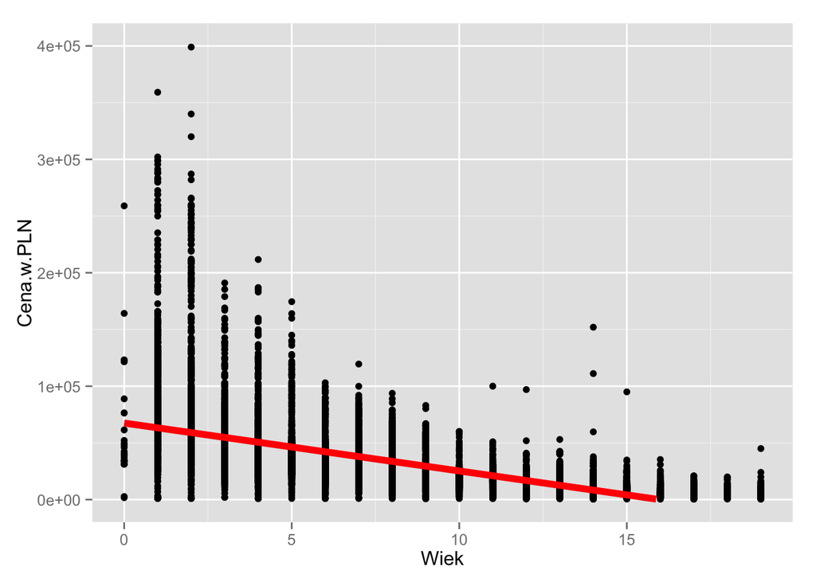

```r
ggplot(volkswagen, aes(y=Cena.w.PLN, x = Wiek)) +
  geom_point() +
  geom_smooth(method="lm", col="red", size=2) +
  ylim(0,400000)
```

Gdyby bezrefleksyjnie przyjąć wyniki estymacji, okazałoby się, że zależność pomiędzy ceną a wiekiem opisana jest przez równanie *Średnia cena = 67640.352 - 4236.639 * Wiek*

Nieufność powinna w nas wzbudzić obserwacja, że podstawiając do tego wzoru za wiek 16 lub więcej lat, okaże się, że otrzymujemy oszacowanie średniej ceny ujemne. Jest to jeden z sygnałów, że coś jest nie tak z naszym modelem.

### Zadania:

- Czy Volkswagen jest wyjątkowy pod tym względem? Zobacz jak wygląda zależność pomiędzy ceną a wiekiem dla innych marek. Dziesięć najczęstszych marek w tym zbiorze danych to `Volkswagen, Opel, Ford, Renault, Audi, Mercedes-Benz, BMW, Peugeot, Lkoda, Fiat`

### Odpowiedzi:

```r
toyota <- auta2012 %>%
  filter(Marka == "Toyota") %>%
  mutate(Wiek = 2012 - Rok.produkcji) %>%
  filter(Wiek < 20)

lm(Cena.w.PLN ~ Wiek, data=toyota)$coef
```

```
## (Intercept)        Wiek
##       70624       -4928
```

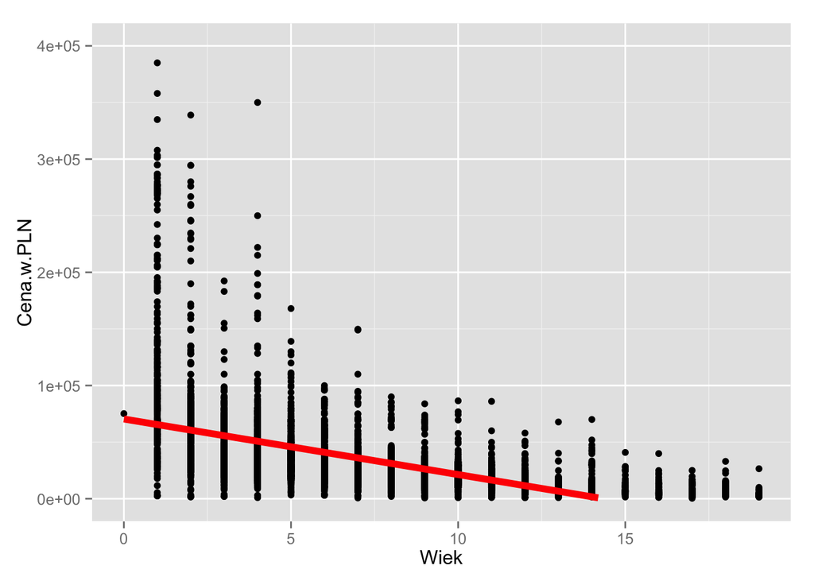

```r
ggplot(toyota, aes(y=Cena.w.PLN, x = Wiek)) +
  geom_point() +
  geom_smooth(method="lm", col="red", size=2) +
  ylim(0,400000)
```

## Jeżeli nie liniowa, to jaka?

Gdy się zastanowić, łatwo dojść do wniosku, że auta tracą na wartości najwięcej w pierwszych latach, gdy są najdroższe. Starsze auta są już tańsze i mniej tracą na wartości. Nie dotyczy to antyków, ale analizowane volkswageny nie są antykami (dlatego mamy tylko auta młodsze niż 20 lat).

Model, który możemy rozważyć, to model w którym co roku auta tracą pewien procent swojej ceny. Taką zależność można opisać jako

*Cena.w.roku.i+1 = Cena.w.roku.i * (1-procent) = Cena.w.roku.i * wsp*

i równoważnie

*Cena.w.roku.i = Cena.w.roku.0 * (1-procent)^i = Cena.w.roku.0 * wsp^i*

Takie zależności nazywamy multiplikatywnymi. Można je sprowadzić co zależności liniowych logarytmując obie strony. (Tak, logarytmy się przydają).

*log(Cena.w.roku.i) = log(Cena.w.roku.0) + log(wsp) * i*

czyli zmieniając zapis

*log(Cena) = b0 + b1 * Wiek*

A to już wygląda jak model liniowy!

Zobaczmy najpierw, jak te dane wyglądać będą, jeżeli ceny przedstawimy w skali logarytmicznej.

```
## geom_smooth: method="auto" and size of largest group is >=1000, so using gam with formula: y ~ s(x, bs = "cs"). Use 'method = x' to change the smoothing method.
```

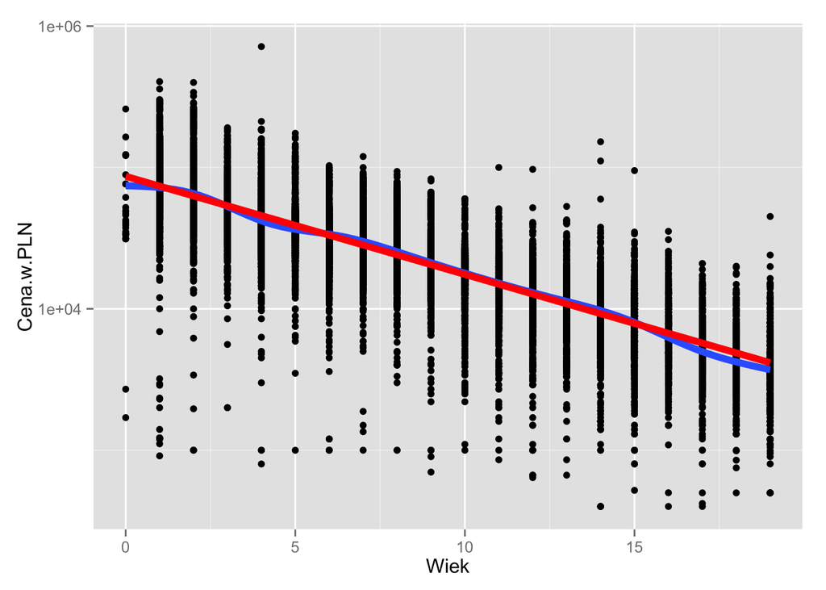

```r
ggplot(volkswagen, aes(y=Cena.w.PLN, x = Wiek)) +
  geom_point() +
  geom_smooth(size=2) + geom_smooth(method="lm", col="red", size=2) +
  scale_y_continuous(trans="log10")
```

Na rysunku ta zależność wygląda na liniową.

Zobaczmy jak wykonać model liniowy z użyciem funkcji `lm()`. Wpierw musimy policzyć logarytm ceny.

```r
volkswagen <- volkswagen %>%
  mutate(logCena.w.PLN = log10(Cena.w.PLN))

(wsp = lm(logCena.w.PLN ~ Wiek, data=volkswagen)$coef)
```

```
## (Intercept)        Wiek
##     4.93716    -0.06938
```

Drugi współczynnik wynosi `-0.0694`, co oznacza, że cena w kolejnym roku to `0.8524` ceny z poprzedniego roku, czyli przecietnie, corocznie auto traci 15% swojej ceny.

### Zadania:

- Wykonaj modelowanie z użyciem modelu multiplikatywnego dla innej marki.
- Jeżeli model multiplikatywny wygląda na uzasadniony, policz ile procent corocznie traci na cenie auto danej marki.

### Odpowiedzi:

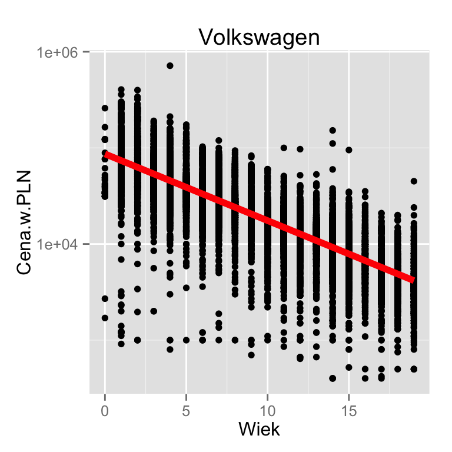

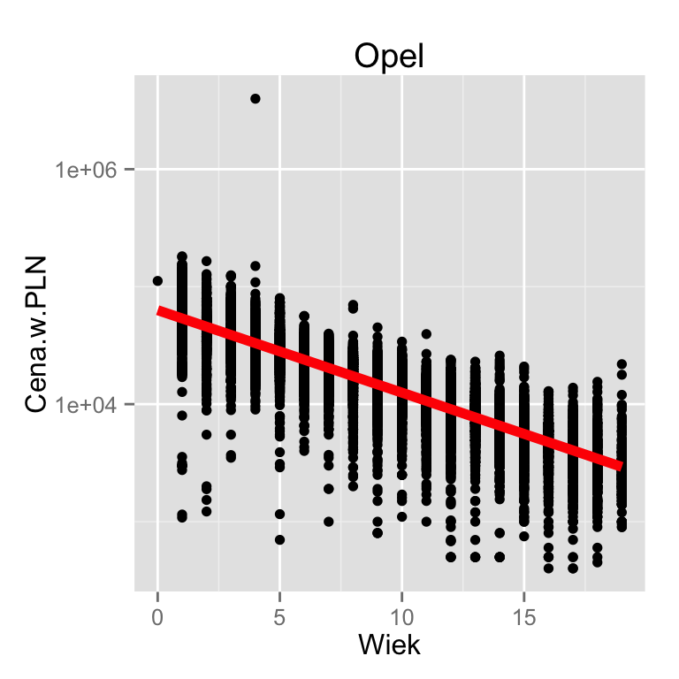

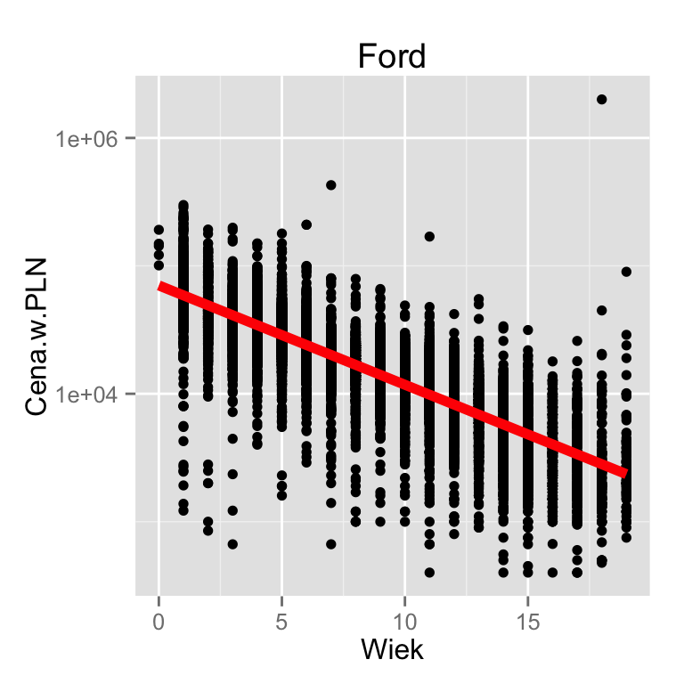

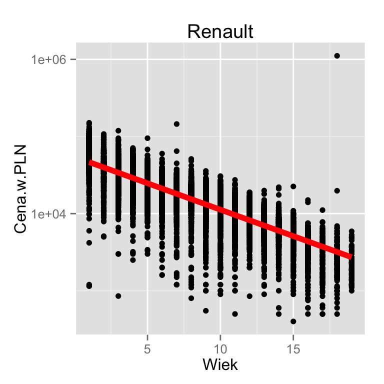

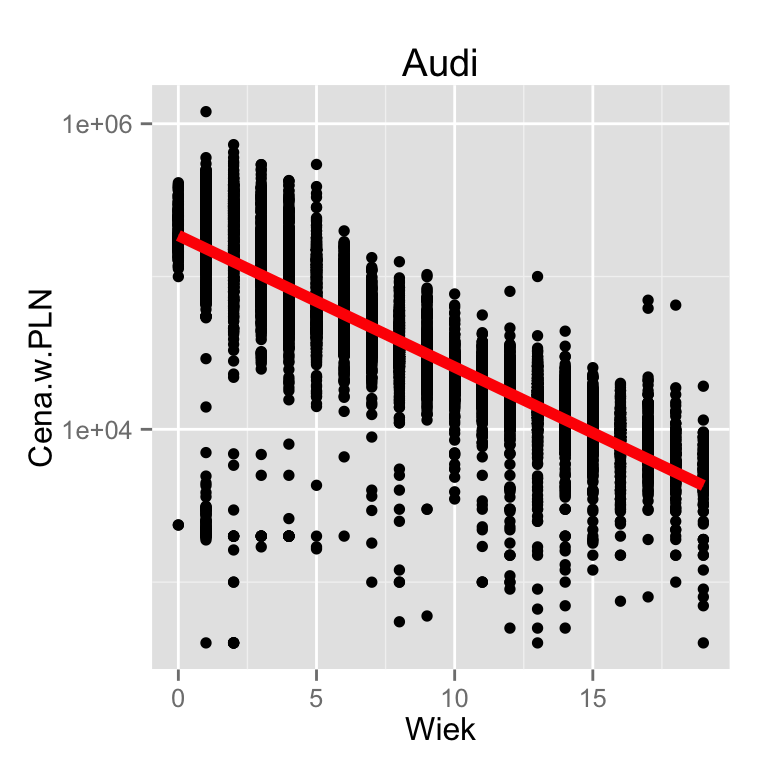

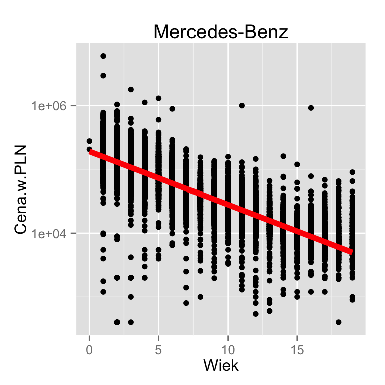

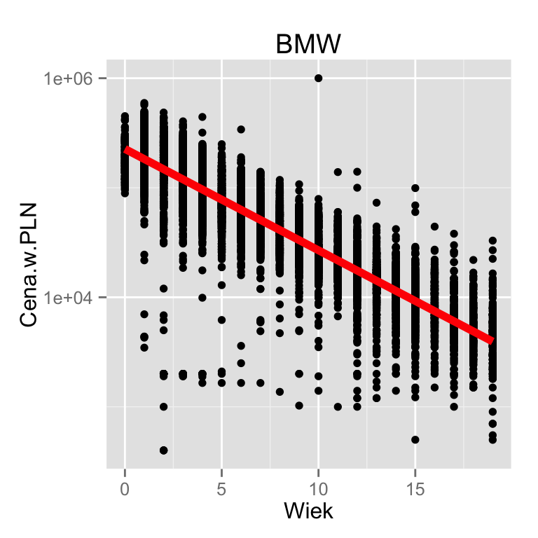

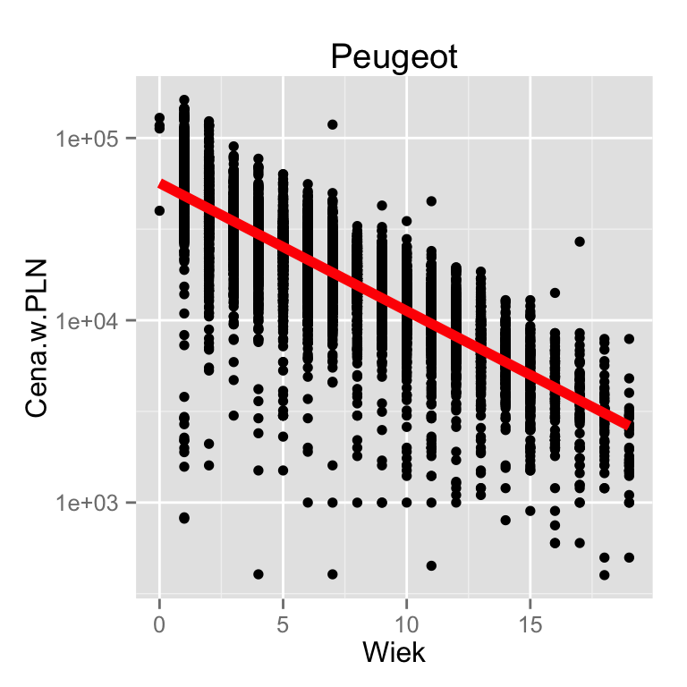

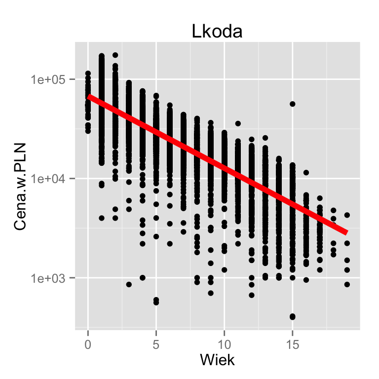

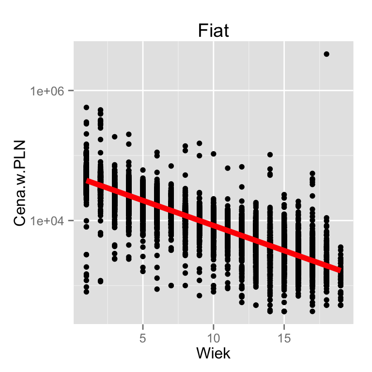

```
##    Volkswagen.Wiek          Opel.Wiek          Ford.Wiek
##               14.8               14.9               16.4
##       Renault.Wiek          Audi.Wiek Mercedes-Benz.Wiek
##               14.6               18.0               17.4
##           BMW.Wiek       Peugeot.Wiek         Lkoda.Wiek
##               19.2               14.9               15.4
##          Fiat.Wiek
##               16.3
```

```r
marki <- names(head(rev(sort(table(auta2012$Marka))),10))
sapply(marki, function(marka) {
  wybranamarka <- auta2012 %>%
    filter(Marka == marka) %>%
    mutate(Wiek = 2012 - Rok.produkcji) %>%
    filter(Wiek < 20) %>%
    mutate(logCena.w.PLN = log10(Cena.w.PLN))

  plot(ggplot(wybranamarka, aes(y=Cena.w.PLN, x = Wiek)) +
    geom_point() +
    geom_smooth(method="lm", col="red", size=2) +
    ggtitle(marka) + scale_y_continuous(trans="log10"))

  wsp <- lm(logCena.w.PLN ~ Wiek, data=wybranamarka)$coef
  procent <- 1- 10^(wsp[2])
  round(100*procent,1)
} )
```

## Przebieg a wiek auta

Przyjrzymy się jak modelować zależność pomiędzy dwoma zmiennymi, przebiegiem samochodu oraz jego wiekiem.

Przyjrzyjmy się zależności pomiędzy przebiegiem a rokiem produkcji

### Czyszczenie danych

Zanim rozpoczniemy jakiekolwiek modelowanie musimy wpierw przyjrzeć się danym.

W modelowaniu obowiązuje żelazna zasada *śmieci na wejściu — śmieci na wyjściu* (ang. garbage in, garbage out). Bez względu na to jakie metody będziemy wykorzystywać, jeżeli w danych są błędy to nasze modelowanie prowadzić może do bezsensownych wniosków.

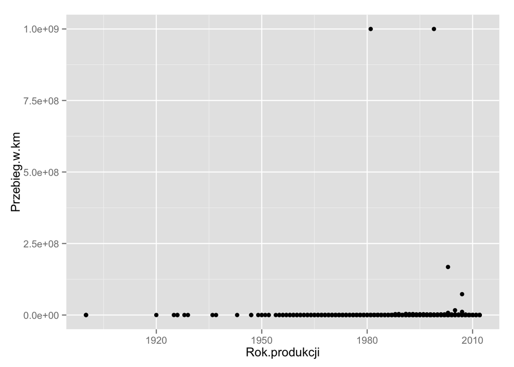

```r
library(ggplot2)
ggplot(auta2012, aes(y=Przebieg.w.km, x = Rok.produkcji)) +
  geom_point()
```

```
## geom_smooth: method="auto" and size of largest group is >=1000, so using gam with formula: y ~ s(x, bs = "cs"). Use 'method = x' to change the smoothing method.
```

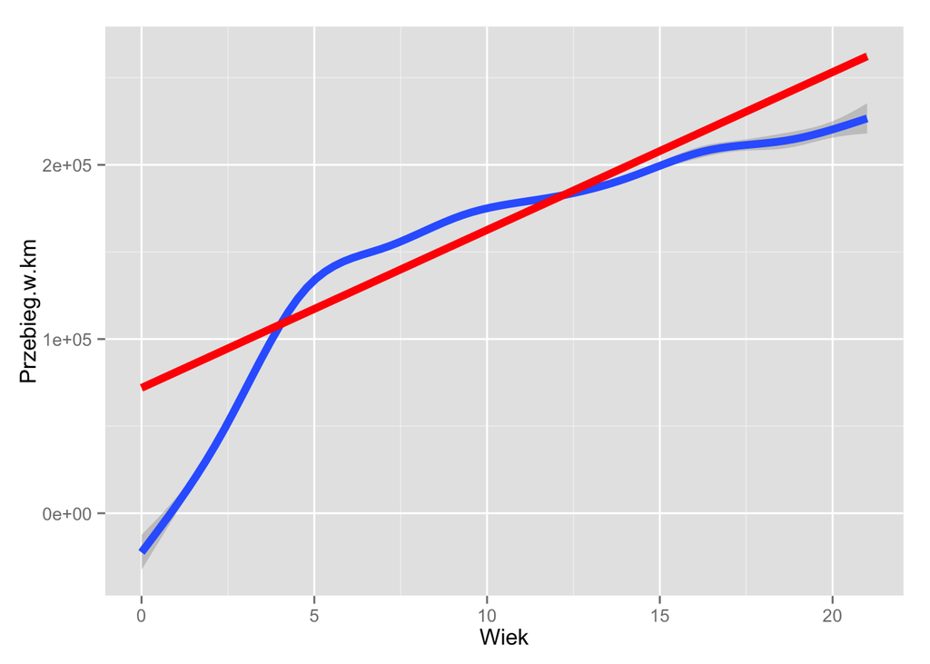

```r
library(dplyr)
auta2012wyczyszczone <- auta2012 %>%
  mutate(Wiek = 2012 - Rok.produkcji) %>%
  filter(Przebieg.w.km < 1000000,
         Rok.produkcji > 1990,
         Marka == "Volkswagen")

ggplot(auta2012wyczyszczone, aes(y=Przebieg.w.km, x = Wiek)) +
  geom_smooth(size=2) + geom_smooth(method="lm", col="red", size=2)
```

Konkurencyjne modele

```r
summary(lm(Przebieg.w.km ~ Wiek - 1, data=auta2012wyczyszczone))
```

```
##
## Call:
## lm(formula = Przebieg.w.km ~ Wiek - 1, data = auta2012wyczyszczone)
##
## Residuals:
##     Min      1Q  Median      3Q     Max
## -321748  -21938   13161   56018  518349
##
## Coefficients:
##      Estimate Std. Error t value Pr(>|t|)
## Wiek  15330.3       45.7     335   <2e-16 ***
## ---
## Signif. codes:  0 '***' 0.001 '**' 0.01 '*' 0.05 '.' 0.1 ' ' 1
##
## Residual standard error: 64200 on 18543 degrees of freedom
## Multiple R-squared:  0.858,  Adjusted R-squared:  0.858
## F-statistic: 1.12e+05 on 1 and 18543 DF,  p-value: <2e-16
```

```r
summary(lm(Przebieg.w.km ~ Wiek, data=auta2012wyczyszczone))
```

```
##
## Call:
## lm(formula = Przebieg.w.km ~ Wiek, data = auta2012wyczyszczone)
##
## Residuals:
##     Min      1Q  Median      3Q     Max
## -262121  -37128    3585   37189  477712
##
## Coefficients:
##             Estimate Std. Error t value Pr(>|t|)
## (Intercept)  71968.7      933.9    77.1   <2e-16 ***
## Wiek          9063.8       90.5   100.1   <2e-16 ***
## ---
## Signif. codes:  0 '***' 0.001 '**' 0.01 '*' 0.05 '.' 0.1 ' ' 1
##
## Residual standard error: 55900 on 18542 degrees of freedom
## Multiple R-squared:  0.351,  Adjusted R-squared:  0.351
## F-statistic: 1e+04 on 1 and 18542 DF,  p-value: <2e-16
```

```r
auta2012wyczyszczone <- auta2012wyczyszczone %>%
  mutate(Wiekponizej5 = ifelse(Wiek < 5, Wiek, 5),
         Wiekpowyzej5 = ifelse(Wiek >= 5, Wiek, 0))

summary(lm(Przebieg.w.km ~ Wiekponizej5 + Wiekpowyzej5, data=auta2012wyczyszczone))
```

```
##
## Call:
## lm(formula = Przebieg.w.km ~ Wiekponizej5 + Wiekpowyzej5, data = auta2012wyczyszczone)
##
## Residuals:
##     Min      1Q  Median      3Q     Max
## -226739  -29286    1458   31181  449098
##
## Coefficients:
##              Estimate Std. Error t value Pr(>|t|)
## (Intercept)  -13232.2     2261.3   -5.85    5e-09 ***
## Wiekponizej5  26762.9      571.7   46.81   <2e-16 ***
## Wiekpowyzej5   5064.0       94.8   53.41   <2e-16 ***
## ---
## Signif. codes:  0 '***' 0.001 '**' 0.01 '*' 0.05 '.' 0.1 ' ' 1
##
## Residual standard error: 52400 on 18541 degrees of freedom
## Multiple R-squared:  0.429,  Adjusted R-squared:  0.429
## F-statistic: 6.97e+03 on 2 and 18541 DF,  p-value: <2e-16
```

```
## geom_smooth: method="auto" and size of largest group is >=1000, so using gam with formula: y ~ s(x, bs = "cs"). Use 'method = x' to change the smoothing method.
```

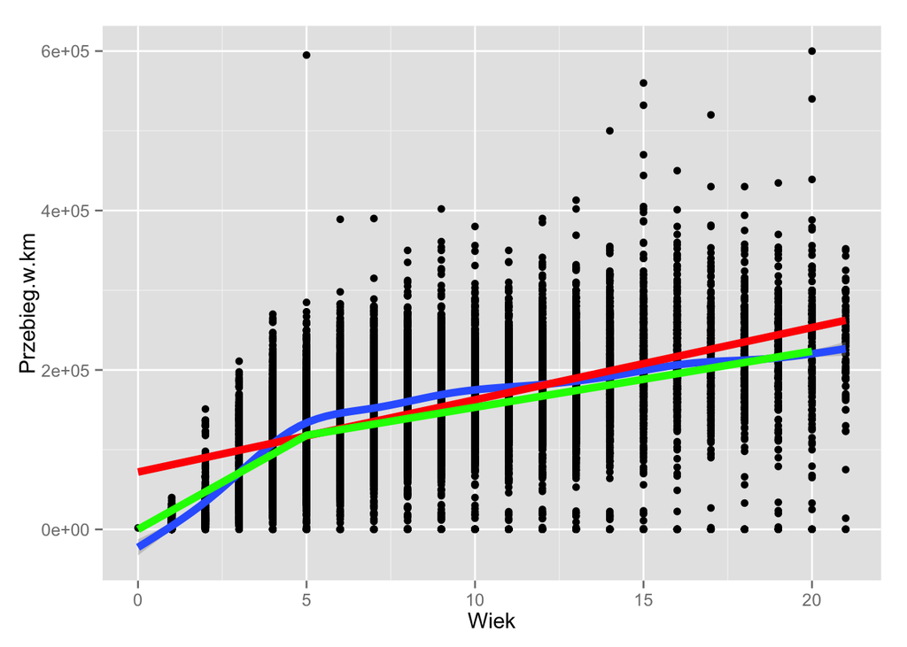

```r
M <- summary(lm(Przebieg.w.km ~ Wiekponizej5 + Wiekpowyzej5 - 1, data=auta2012wyczyszczone))

pred <- data.frame(Wiek = c(0,5,20), Przebieg.w.km = c(0,5*M$coefficients[1,1],20*M$coefficients[2,1]+5*M$coefficients[1,1]))

ggplot(auta2012wyczyszczone, aes(y=Przebieg.w.km, x = Wiek)) +
  geom_point() +
  geom_smooth(size=2) + geom_smooth(method="lm", col="red", size=2) +
  geom_line(data= pred, aes(y=Przebieg.w.km, x = Wiek), size=2, col="green")
```

### Zadania:

### Odpowiedzi: